# Startups-An EDA

Deepak Kumar G S

October 25, 2017

# Introduction:

- This dataset contains information on startup name,industry vertical,location,investors of the startup etc.
- We try to understand the dataset by answering questions like which startup is funded the most,which is the prefered industry verical for investors,which city are startups prefering etc..

# Loading the required libraries,data and glimpse into the dataset:

```r
library(plyr)
library(dplyr)
library(ggplot2)
library(ggthemes)
library(knitr)
library(kableExtra)
library(cowplot)
library(tidyr)
library(stringr)
library(zoo)
library(splitstackshape)
library(viridis)
library(ggrepel)
library(forcats)
star=read.csv("startup_funding.csv",header=TRUE,stringsAsFactors = FALSE)
glimpse(star)
```

```
## Observations: 2,372
## Variables: 10
## $ SNo              <int> 0, 1, 2, 3, 4, 5, 6, 7, 8, 9, 10, 11, 12, 13,...
## $ Date             <chr> "01/08/2017", "02/08/2017", "02/08/2017", "02...
## $ StartupName      <chr> "TouchKin", "Ethinos", "Leverage Edu", "Zepo"...
## $ IndustryVertical <chr> "Technology", "Technology", "Consumer Interne...
## $ SubVertical      <chr> "Predictive Care Platform", "Digital Marketin...
## $ CityLocation     <chr> "Bangalore", "Mumbai", "New Delhi", "Mumbai",...
## $ InvestorsName    <chr> "Kae Capital", "Triton Investment Advisors", ...
## $ InvestmentType   <chr> "Private Equity", "Private Equity", "Seed Fun...
## $ AmountInUSD      <chr> "1,300,000", "", "", "500,000", "850,000", "1...
## $ Remarks          <chr> "", "", "", "", "", "", "", "", "", "", "", "...
```

```r
summary(star)
```

```
##       SNo             Date           StartupName        IndustryVertical
##  Min.   :   0.0   Length:2372        Length:2372        Length:2372
##  1st Qu.: 592.8   Class :character   Class :character   Class :character
##  Median :1185.5   Mode  :character   Mode  :character   Mode  :character
##  Mean   :1185.5
##  3rd Qu.:1778.2
##  Max.   :2371.0
##  SubVertical        CityLocation       InvestorsName
##  Length:2372        Length:2372        Length:2372
##  Class :character   Class :character   Class :character
##  Mode  :character   Mode  :character   Mode  :character
##
##
##
##  InvestmentType     AmountInUSD          Remarks
##  Length:2372        Length:2372        Length:2372
##  Class :character   Class :character   Class :character
##  Mode  :character   Mode  :character   Mode  :character
##
##
##
```

# Which year has seen more fundings?

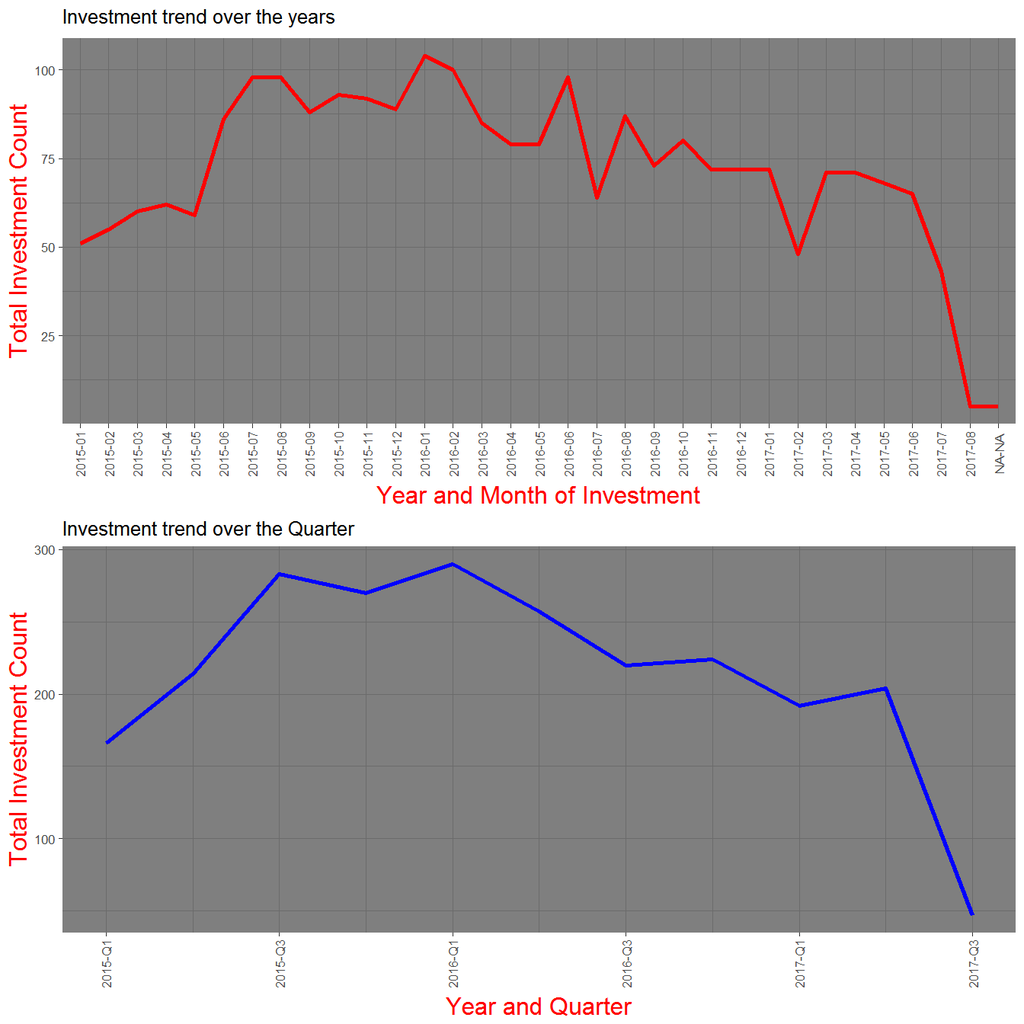

```r
star$Date=as.POSIXct(strptime(star$Date,format="%d/%m/%Y")) # converting into date format
star$Month=as.factor(format(star$Date,"%m"))
star$Year=as.factor(format(star$Date,"%Y"))
star$Monyr=paste(star$Year,star$Month,sep="-")
temp= star %>% group_by(Monyr) %>% summarise(Investments=n())  # count by month,year
p=ggplot(temp,aes(Monyr,Investments,group=1))+geom_line(color="red",size=1)+theme_dark(base_size=8)+labs(x="Year and Month of Investment",y="Total Investment Count",title="Investment trend over the years")+theme(axis.title=element_text(color="red",family="sans",size=12),axis.text.x = element_text(angle=90,vjust=0.5))# Plot of the year,month trend
#Quaterly trend:
star$Qtr=as.yearqtr(star$Date,format="%y-Q%q")
temp=star %>% group_by(Qtr) %>% summarise(Investment=n()) %>% drop_na(Qtr)
q=ggplot(temp,aes(Qtr,Investment,group=1))+geom_line(color="blue",size=1)+theme_dark(base_size=8)+labs(x="Year and Quarter",y="Total Investment Count",title="Investment trend over the Quarter")+theme(axis.title=element_text(color="red",family="sans",size=12),axis.text.x = element_text(angle=90,vjust=0.5))+scale_x_yearqtr(format="%Y-Q%q")
plot_grid(p,q,ncol=1)
```

# Trend of Quarterly Funding:

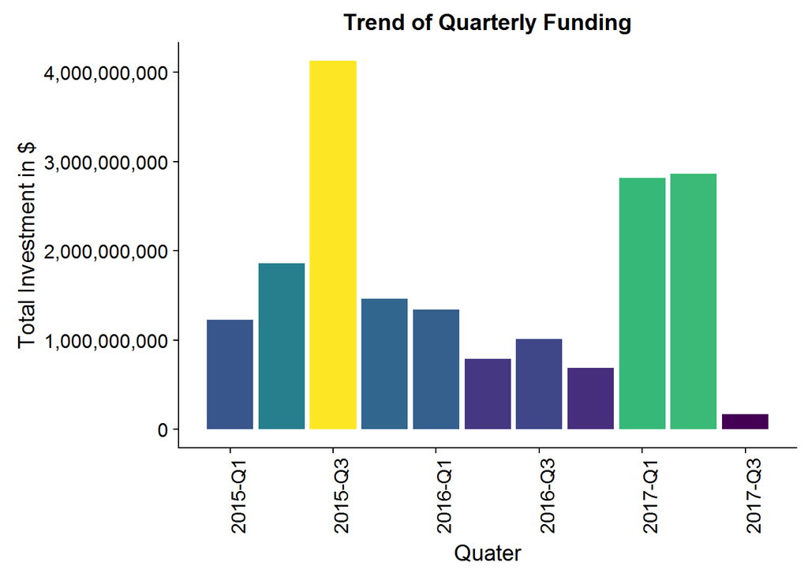

```r
star$AmountInUSD=as.numeric(gsub(",","",star$AmountInUSD)) #Changed from char to numeric and removed comma
temp=ddply(star,.(Qtr),summarise,TotalInvestments=sum(AmountInUSD,na.rm=TRUE))
temp%>% drop_na(Qtr) %>% ggplot(aes(Qtr,TotalInvestments,fill=TotalInvestments))+geom_bar(stat="identity")+labs(x="Quater",y="Total Investment in $",title="Trend of Quarterly Funding")+theme(axis.text.x=element_text(angle=90),legend.position="none")+scale_x_yearqtr(format="%Y-Q%q")+scale_fill_viridis(discrete = FALSE)+scale_y_continuous(labels=scales::comma)
```

# Breakdown of Investment Locations:

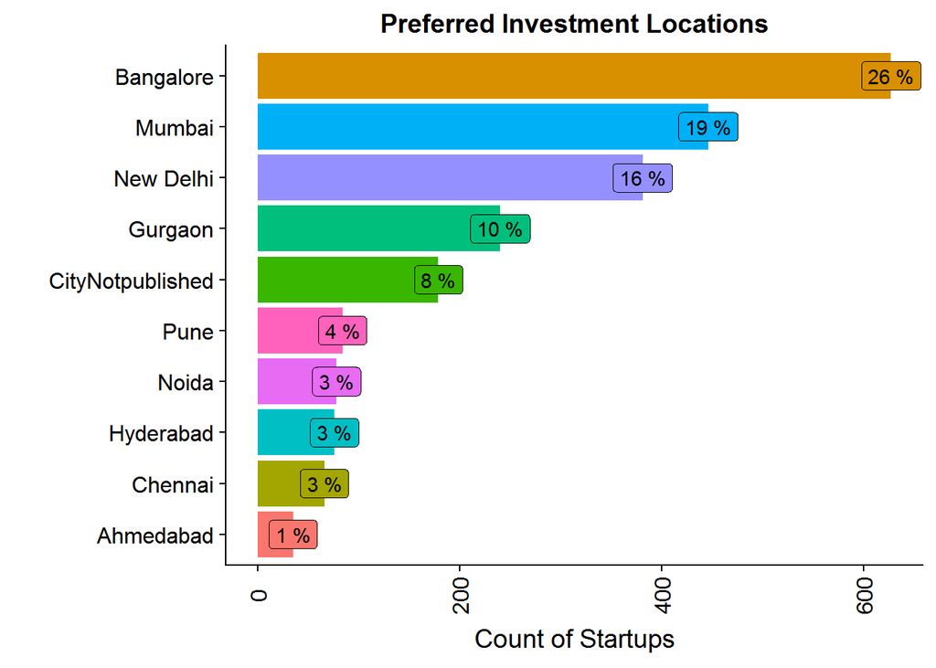

```r
temp=star %>% select(CityLocation) %>% group_by(CityLocation) %>% summarise(count=n()) %>% mutate(perc=round((count/sum(count))*100)) %>% arrange(desc(count)) # Top 10 Cities
temp[temp==""]="CityNotpublished" # replace blank with this
temp$perc=paste(temp$perc,"%") # add % to the column
ggplot(head(temp,10),aes(reorder(CityLocation,count),count,fill=CityLocation))+geom_bar(stat="identity")+theme(legend.position="none",axis.text.x = element_text(angle=90,vjust=0.5))+labs(x="",y="Count of Startups",title="Preferred Investment Locations")+geom_label(aes(label=perc))+coord_flip() # visualise along with %
```

26 % of the startups find Bangalore for starting their venture followed by Mumbai and New Delhi.

# Breakdown of Industry Vertical:

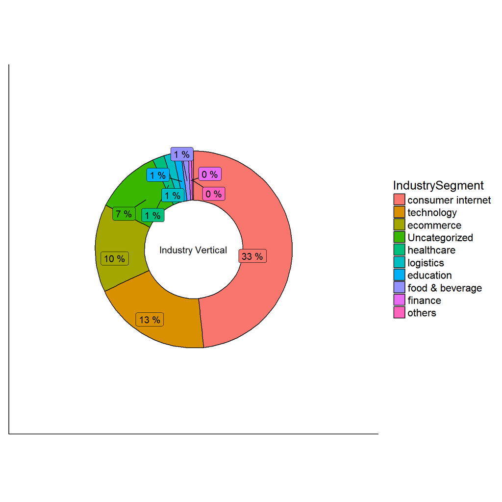

```r
star$IndustryVertical=tolower(star$IndustryVertical)
star$IndustryVertical[star$IndustryVertical==""]="Uncategorized"
temp=star %>% select(IndustryVertical) %>% group_by(IndustryVertical) %>% drop_na(IndustryVertical)%>% summarise(count=n()) %>% mutate(perc=(count/sum(count))*100) %>% arrange(desc(count))#finding percentage and count
temp$ymax=cumsum(temp$perc) #for donut
temp$ymin=c(0,head(temp$ymax,n=-1))
temp$IndustryVertical=factor(temp$IndustryVertical,levels=temp$IndustryVertical)
ggplot(head(temp,10),aes(fill=IndustryVertical,ymax=ymax,ymin=ymin,xmax=10,xmin=5))+geom_rect(color="black")+coord_polar(theta="y")+xlim(c(0,15))+geom_label_repel(aes(label=paste(round(perc),"%"),x=7,y=(ymax+ymin)/2),inherit.aes=TRUE,show.legend=FALSE)+theme(panel.grid = element_blank(),axis.text = element_blank(),axis.ticks = element_blank(),legend.position="right",axis.title=element_blank()) +annotate("text", x = 0, y = 0 ,label = "Industry Vertical")+labs(fill="IndustrySegment")+guides(fill=guide_legend(keywidth=1,keyheight=1))
```

Consumer Internet is the prefered model of business for 33 % of the startups followed by technology and e commerce.

# Breakdown of Investment Type:

```r
unique(star$InvestmentType)
```

```
## [1] "Private Equity" "Seed Funding"   "Debt Funding"   ""
## [5] "SeedFunding"    "PrivateEquity"  "Crowd funding"  "Crowd Funding"
```

There seems to be duplicate values and we need to clean it a bit.For eg.CrowdFunding and Crowd Funding are same but it is interpreted differently.Lets clean it and resummarise.

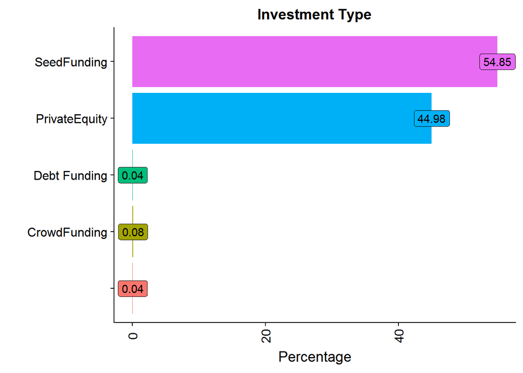

```r
star$InvestmentType=as.factor(star$InvestmentType)
star=star %>% mutate(InvestmentType=fct_collapse(InvestmentType,"PrivateEquity"=c("PrivateEquity","Private Equity"),"SeedFunding"=c("SeedFunding","Seed Funding"),"CrowdFunding"=c("Crowd Funding","Crowd funding")))#rename factor
temp = star %>% group_by(InvestmentType)%>% summarise(count=n()) %>% mutate(perc=(round(count/sum(count)*100,2))) %>% arrange(desc(count))

ggplot(temp,aes(InvestmentType,perc,fill=InvestmentType)) +geom_bar(stat="identity")+theme(legend.position="none",axis.text.x = element_text(angle=90,vjust=0.5))+labs(x="",y="Percentage",title="Investment Type")+geom_label(aes(label=perc))+coord_flip()
```

More than 54 % of the investors have seed funded the startups while 45 % of them are through private equity.

# Which startup has investors confidence ?

```r
temp=star %>% select(StartupName,InvestorsName,AmountInUSD) %>% ddply(.(StartupName),summarise,sum=sum(AmountInUSD)) %>% arrange(desc(sum))
kable(head(temp,25),"html") %>% kable_styling("striped",full_width=T) %>% column_spec(1:2,bold=T,background="white") %>% row_spec(c(1,2,3,5,6,24,25),bold=F,color="white",background="#ffb6c1")
```

| StartupName | sum |
| --- | --- |
| Flipkart | 1559700000 |
| Ola | 984500000 |
| Flipkart.com | 700000000 |
| Snapdeal | 700000000 |
| Olacabs | 400000000 |
| Oyo Rooms | 350000000 |
| Quikr | 230000000 |
| Delhivery | 215000000 |
| Foodpanda | 210000000 |
| BigBasket | 207000000 |
| Paytm Marketplace | 200000000 |
| MakeMyTrip | 180000000 |
| Hike | 175000000 |
| Swiggy | 170500000 |
| Grofers | 165000000 |
| CarTrade | 145000000 |
| Ecom Express | 137000000 |
| FreeCharge | 137000000 |
| Pepperfry | 131300000 |
| Rivigo | 120000000 |
| Shopclues | 107700000 |
| Fractal Analytics | 100000000 |
| Inmobi | 100000000 |
| Oyo | 100000000 |
| Oyorooms | 100000000 |

An birdseye view of the data indicates that the startup variable requires some cleaning.We try to remove .com,in from the variable and combine certain rows since they represent the same company.

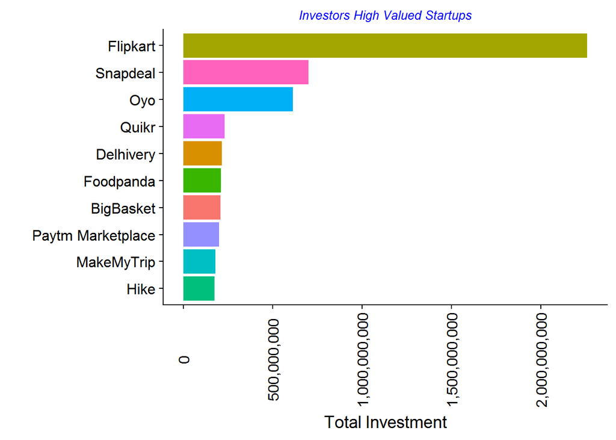

```r
star$StartupName=sapply(strsplit(star$StartupName,split=".com",fixed=TRUE),function(x)(x[1]))
star$StartupName=sapply(strsplit(star$StartupName,split=".in",fixed=TRUE),function(x)(x[1]))
star$StartupName=sapply(strsplit(star$StartupName,split=".co",fixed=TRUE),function(x)(x[1]))
star$StartupName=as.factor(star$StartupName)
star =star %>% mutate(StartupName=fct_collapse(StartupName,"Oyo"=c("Oyo","Oyorooms","Oyo Rooms","OyoRooms"),"Ola"=c("Ola","Olacabs","Ola Cabs")))
temp=star %>% select(StartupName,InvestorsName,AmountInUSD) %>% ddply(.(StartupName),summarise,sum=sum(AmountInUSD)) %>% arrange(desc(sum))
#Top 10
ggplot(head(temp,10),aes(reorder(StartupName,sum),sum,fill=StartupName))+geom_bar(stat="identity")+theme(legend.position="none",axis.text.x = element_text(angle=90,vjust=0.5),plot.title=element_text(color="blue",size=10,face="italic"))+labs(x="",y="Total Investment",title="Investors High Valued Startups")+coord_flip()+scale_y_continuous(labels=scales::comma)
```

# Top Investors:

To find out the top investors,we need to split the investor name column so that each column consists of 1 investor name instead of several investors.The *splitstackshape* package comes in handy for this scenerio since the number of colums to be split is not known because there are unequal number of investors for each startup.We use the cSplit function to split the columns.

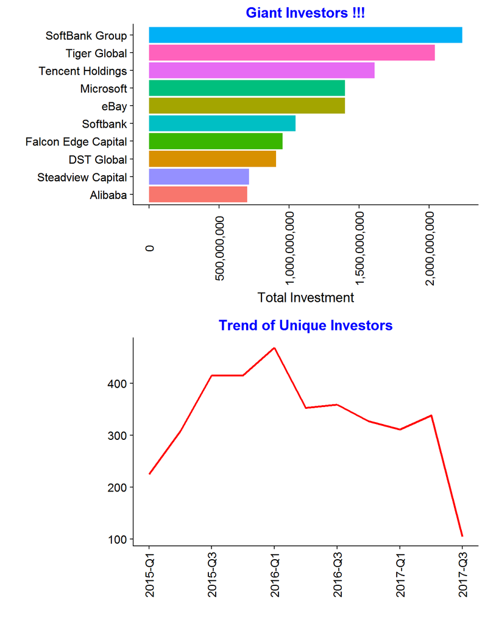

```r
star=cSplit(star,"InvestorsName",sep=",",direction="long",drop=FALSE)
temp=ddply(star,.(InvestorsName),summarise,count=n(),TotalInvestment=sum(AmountInUSD))
temp=temp %>% arrange(desc(TotalInvestment)) %>% drop_na(TotalInvestment)
p=ggplot(head(temp,10),aes(reorder(InvestorsName,TotalInvestment),TotalInvestment,fill=InvestorsName))+geom_bar(stat="identity")+theme(legend.position="none",axis.text.x = element_text(angle=90,vjust=0.5),plot.title=element_text(color="blue",size=15,face="bold",hjust=0.5))+labs(x="",y="Total Investment",title="Giant Investors !!!")+coord_flip()+scale_y_continuous(labels=scales::comma)

#Trend of Unique Investors
temp=star %>% select(Qtr,InvestorsName) %>% group_by(Qtr) %>% drop_na(Qtr)%>% mutate(count=length(unique(InvestorsName)))
q=ggplot(temp[(!duplicated(c("Qtr","count"))),],aes(Qtr,count))+geom_line(color="red",size=1)+scale_x_yearqtr(format="%Y-Q%q")+theme(legend.position="none",axis.text.x = element_text(angle=90,vjust=0.5),plot.title=element_text(color="blue",size=15,face="bold",hjust=0.5))+labs(x="",y="",title="Trend of Unique Investors")
plot_grid(p,q,align='v',ncol=1)
```

Investor funding took an increase with more than 400+ unique investors entering into startup ecosystem in Q1 of 2016 which has shown a declining trend since then.

We select the top 5 investors to know in which startups they have pumped their investments.

# Investor Funding

## Softbank Group

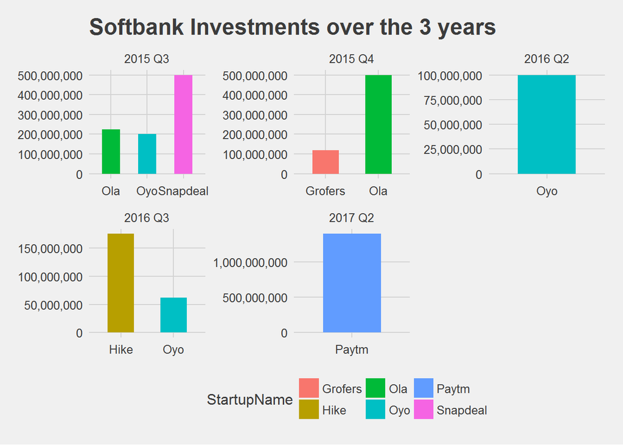

```r
temp= star %>% filter(InvestorsName=="SoftBank Group" | InvestorsName=="Softbank") %>% select(Qtr,StartupName,AmountInUSD) %>% ddply(.(Qtr,StartupName),summarise,TotalInvestment=sum(AmountInUSD))
ggplot(temp,aes(x=StartupName,y=TotalInvestment,fill=StartupName))+geom_bar(stat="identity",position="identity",width=0.5)+facet_wrap(~Qtr,scales=c("free"))+scale_y_continuous(labels=scales::comma)+theme(legend.position="none",axis.text.x = element_text(angle=90,vjust=0.5),plot.title=element_text(color="blue",size=10,face="italic"))+labs(x="",y="Total Investment",title="Softbank Investments over the 3 years")+theme_fivethirtyeight()
```

## Tiger Global

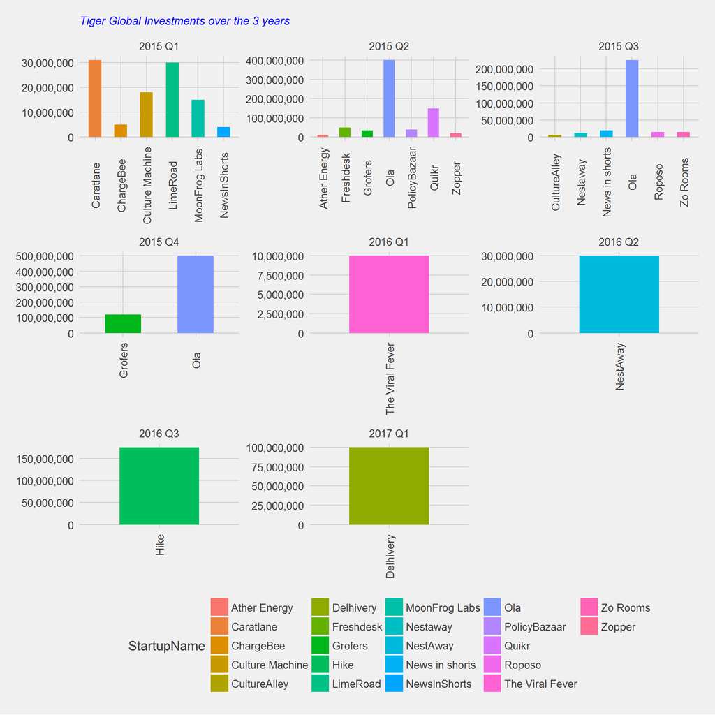

```r
temp= star %>% filter(InvestorsName=="Tiger Global") %>% select(Qtr,StartupName,AmountInUSD) %>% ddply(.(Qtr,StartupName),summarise,TotalInvestment=sum(AmountInUSD))
ggplot(temp,aes(x=StartupName,y=TotalInvestment,fill=StartupName))+geom_bar(stat="identity",position="identity",width=0.5)+facet_wrap(~Qtr,scales=c("free"))+scale_y_continuous(labels=scales::comma)+theme_fivethirtyeight()+theme(axis.text.x = element_text(angle=90,vjust=0.5),plot.title=element_text(color="blue",size=10,face="italic"))+labs(x="",y="Total Investment",title="Tiger Global Investments over the 3 years")
```

## Tencent Holdings

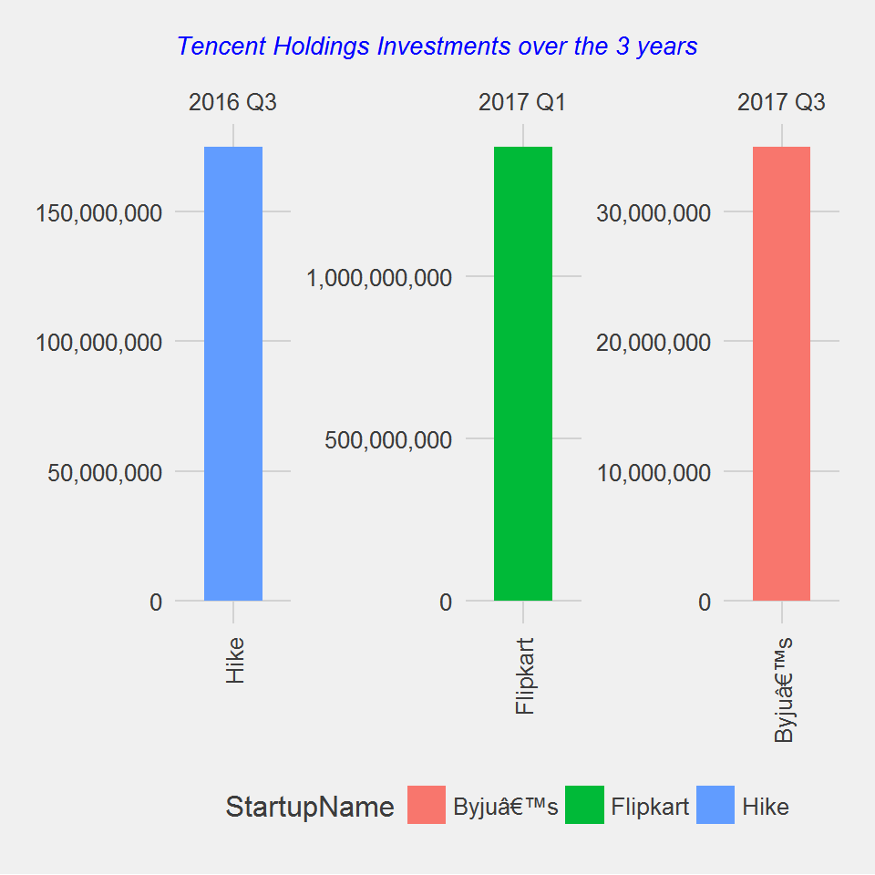

```r
temp= star %>% filter(InvestorsName=="Tencent Holdings") %>% select(Qtr,StartupName,AmountInUSD) %>% ddply(.(Qtr,StartupName),summarise,TotalInvestment=sum(AmountInUSD))
ggplot(temp,aes(x=StartupName,y=TotalInvestment,fill=StartupName))+geom_bar(stat="identity",position="identity",width=0.5)+facet_wrap(~Qtr,scales=c("free"))+scale_y_continuous(labels=scales::comma)+theme_fivethirtyeight()+theme(axis.text.x = element_text(angle=90,vjust=0.5),plot.title=element_text(color="blue",size=10,face="italic"))+labs(x="",y="Total Investment",title="Tencent Holdings Investments over the 3 years")
```

## Microsoft

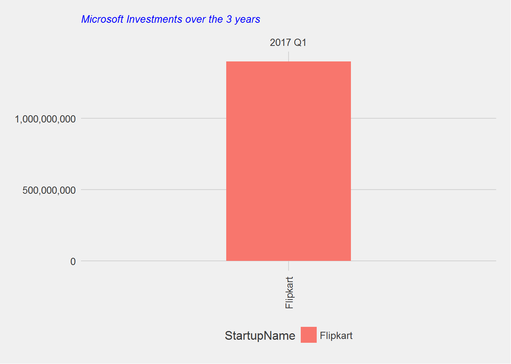

```r
temp= star %>% filter(InvestorsName=="Microsoft") %>% select(Qtr,StartupName,AmountInUSD) %>% ddply(.(Qtr,StartupName),summarise,TotalInvestment=sum(AmountInUSD))
ggplot(temp,aes(x=StartupName,y=TotalInvestment,fill=StartupName))+geom_bar(stat="identity",position="identity",width=0.3)+facet_wrap(~Qtr,scales=c("free"))+scale_y_continuous(labels=scales::comma)+theme_fivethirtyeight()+theme(axis.text.x = element_text(angle=90,vjust=0.5),plot.title=element_text(color="blue",size=10,face="italic"))+labs(x="",y="Total Investment",title="Microsoft Investments over the 3 years")
```

## eBay

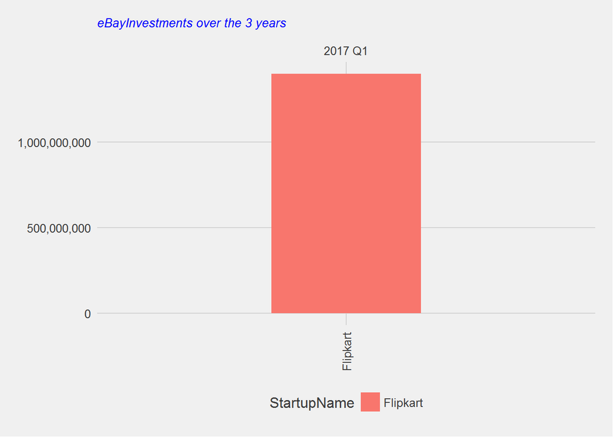

```r
temp= star %>% filter(InvestorsName=="eBay") %>% select(Qtr,StartupName,AmountInUSD) %>% ddply(.(Qtr,StartupName),summarise,TotalInvestment=sum(AmountInUSD))
ggplot(temp,aes(x=StartupName,y=TotalInvestment,fill=StartupName))+geom_bar(stat="identity",position="identity",width=0.3)+facet_wrap(~Qtr,scales=c("free"))+scale_y_continuous(labels=scales::comma)+theme_fivethirtyeight()+theme(axis.text.x = element_text(angle=90,vjust=0.5),plot.title=element_text(color="blue",size=10,face="italic"))+labs(x="",y="Total Investment",title="eBayInvestments over the 3 years")
```

# Conclusion

> The year 2015 seems to be a boom period for startup investments but this has seen a downward trend during the entire 2016.Lot of factors can be attributed to this.

> One event which shook up the Indian Ecosystem is the Demonitisation move by the government in Nov 2016.

> This project has focused to analyse the dataset from differnt angles and has partly tried to find out the top players in the startup space as far as the investments are concerned.

**Thank you for reading.**